# NEON forecast challenge - aquatics

Bibek Kandel

2024-01-30

# This R markdown document

This document presents workshop materials to get you started on generating forecasts specifically for submission to the EFI-NEON Forecasting Challenge. The Challenge goal is to create a community of practice that builds capacity for ecological forecasting by leveraging NEON data products. The Challenge revolves around the five theme areas that span aquatic and terrestrial systems, and population, community, and ecosystem processes across a broad range of ecoregions that uses data collected by NEON. Learn more about the Challenge [here](https://projects.ecoforecast.org/neon4cast-docs/)!

The development of these materials has been supported by NSF grants DEB-1926388 and DBI-1933016.

To complete the workshop via this markdown document the following packages will need to be installed:

- `remotes`
- `fpp3`
- `tsibble`
- `tidyverse`
- `lubridate`
- `neon4cast` (from github)

The following code chunk should be run to install packages.

```r
install.packages('remotes')
install.packages('fpp3') # package for applying simple forecasting methods
install.packages('tsibble') # package for dealing with time series data sets and tsibble objects
install.packages('tidyverse') # collection of R packages for data manipulation, analysis, and visualisation
install.packages('lubridate') # working with dates and times
remotes::install_github('eco4cast/neon4cast', force = TRUE) # package from NEON4cast challenge organisers to assist with forecast building and submission
```

Additionally, R version 4.2 is required to run the neon4cast package. It’s also worth checking your Rtools is up to date and compatible with R 4.2, see (https://cran.r-project.org/bin/windows/Rtools/rtools42/rtools.html).

```r
# install.packages("tidyverse")
# install.packages("lubridate")
# install.packages("RColorBrewer")
# install.packages("ggthemes")
library(tidyverse)
library(lubridate)
library(RColorBrewer)
library(ggthemes)
library(remotes)
library(fpp3)
library(tsibble)
set.seed(100)
```

If you do not wish to run the code yourself you can follow along via the html (NEON_forecast_challenge_workshop.md), which can be downloaded from the [Github repository](https://github.com/OlssonF/NEON-forecast-challenge-workshop).

# Introduction to NEON forecast challenge

The EFI RCN NEON Forecast Challenge asks the scientific community to produce ecological forecasts of future conditions at NEON sites by leveraging NEON’s open data products. The Challenge is split into five themes that span aquatic and terrestrial systems, and population, community, and ecosystem processes across a broad range of ecoregions. We are excited to use this Challenge to learn more about the predictability of ecological processes by forecasting NEON data before it is collected.

Which modeling frameworks, mechanistic processes, and statistical approaches best capture community, population, and ecosystem dynamics? These questions are answerable by a community generating a diverse array of forecasts. The Challenge is open to any individual or team from anywhere around the world that wants to submit forecasts. Sign up [here.](https://projects.ecoforecast.org/neon4cast-docs/Participation.html).

## Aquatics challenge

What: Freshwater surface water temperature, oxygen, and chlorophyll-a.

Where: 7 lakes and 27 river/stream NEON sites.

When: Daily forecasts for at least 30-days in the future. New forecast submissions, that use new data to update the forecast, are accepted daily. The only requirement is that submissions are predictions of the future at the time the forecast is submitted.

Today we will focus on lake sites only and will start with forecasting water temperature. For the challenge, you can chose to submit to either the lakes, rivers or streams or all three! You can also chose to submit any of the three focal variables (temperature, oxygen, and chlorophyll). Find more information about the aquatics challenge [here](https://projects.ecoforecast.org/neon4cast-docs/Aquatics.html).

## Submission requirements

For the Challange, forecasts must include quantified uncertainty. The file can represent uncertainty using an ensemble forecast (multiple realizations of future conditions) or a distribution forecast (with mean and standard deviation), specified in the family and parameter columns of the forecast file.

For an ensemble forecast, the `family` column uses the word `ensemble` to designate that it is a ensemble forecast and the parameter column is the ensemble member number (1, 2, 3 …). For a distribution forecast, the `family` column uses the word `normal` to designate a normal distribution and the parameter column must have the words mu and sigma for each forecasted variable, site_id, and datetime. For forecasts that don’t have a normal distribution we recommend using the ensemble format and sampling from your non-normal distribution to generate a set of ensemble members that represents your distribution. I will go through examples of both `ensemble` and `normal` forecasts as examples.

The full list of required columns and format can be found in the [Challenge documentation](https://projects.ecoforecast.org/neon4cast-docs/Submission-Instructions.html).

# The forecasting workflow

## Read in the data

We start forecasting by first looking at the historic data - called the ‘targets’. These data are available near real-time, with the latency of approximately 24-48 hrs. Here is how you read in the data from the targets file available from the EFI server.

```r
#read in the targets data
targets <- read_csv('https://data.ecoforecast.org/neon4cast-targets/aquatics/aquatics-targets.csv.gz')
```

Information on the NEON sites can be found in the `NEON_Field_Site_Metadata_20220412.csv` file on GitHub. It can be filtered to only include aquatic sites. This table has information about the field sites, including location, ecoregion, information about the watershed (e.g. elevation, mean annual precipitation and temperature), and lake depth.

```r
# read in the sites data
aquatic_sites <- read_csv("https://raw.githubusercontent.com/eco4cast/neon4cast-targets/main/NEON_Field_Site_Metadata_20220412.csv") |>
  dplyr::filter(aquatics == 1)
```

Let’s take a look at the targets data!

```
## # A tibble: 11 × 4
##    datetime   site_id variable    observation
##    <date>     <chr>   <chr>             <dbl>
##  1 2017-04-23 ARIK    temperature       12.7
##  2 2017-04-24 ARIK    chla              NA
##  3 2017-04-24 ARIK    oxygen             7.10
##  4 2017-04-24 ARIK    temperature       14.8
##  5 2017-04-25 ARIK    chla              NA
##  6 2017-04-25 ARIK    oxygen             6.58
##  7 2017-04-25 ARIK    temperature       15.5
##  8 2017-04-26 ARIK    chla              NA
##  9 2017-04-26 ARIK    oxygen             7.32
## 10 2017-04-26 ARIK    temperature       13.0
## 11 2017-04-27 ARIK    chla              NA
```

The columns of the targets file show the time step (daily for aquatics challenge), the 4 character site code (`site_id`), the variable being measured, and the mean daily observation. To look at only the lakes we can subset the targets and aquatic sites to those which have the `field_site_subtype` of `Lake`.

```r
lake_sites <- aquatic_sites %>%
  filter(field_site_subtype == 'Lake')

targets <- targets %>%
  filter(site_id %in% lake_sites$field_site_id)
```

## Visualise the data

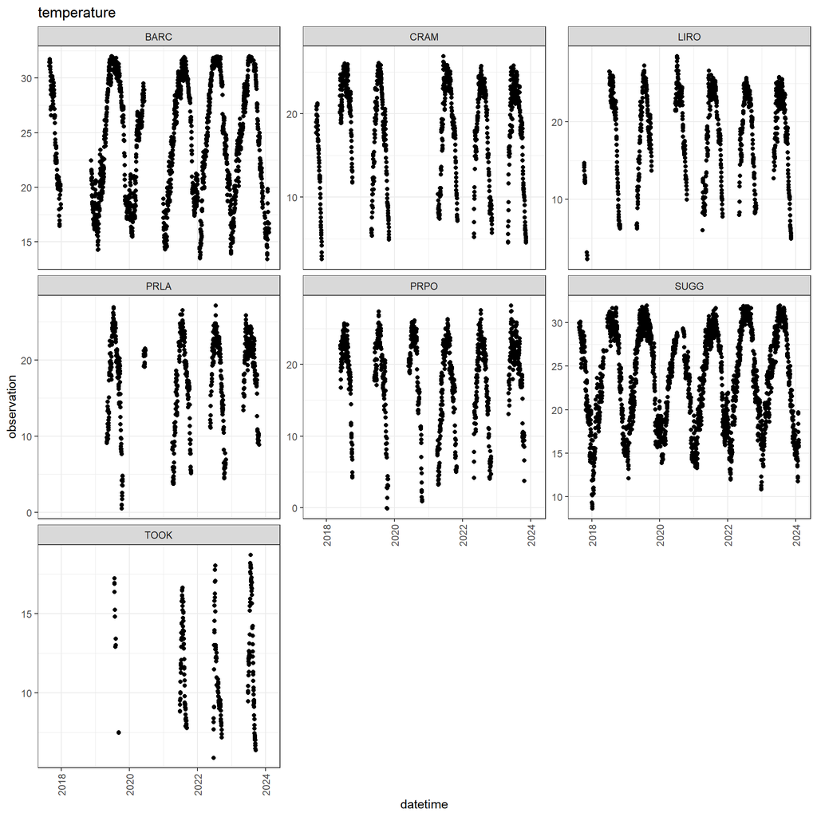

Figure: Temperature targets data at aquatic sites provided by EFI for the NEON forecasting challgenge

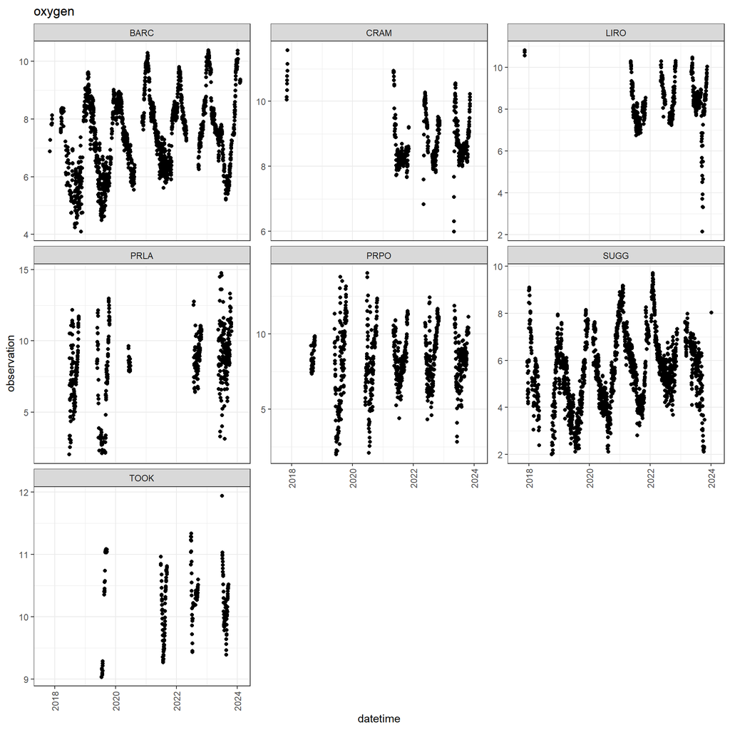

Figure: Oxygen targets data at aquatic sites provided by EFI for the NEON forecasting challgenge

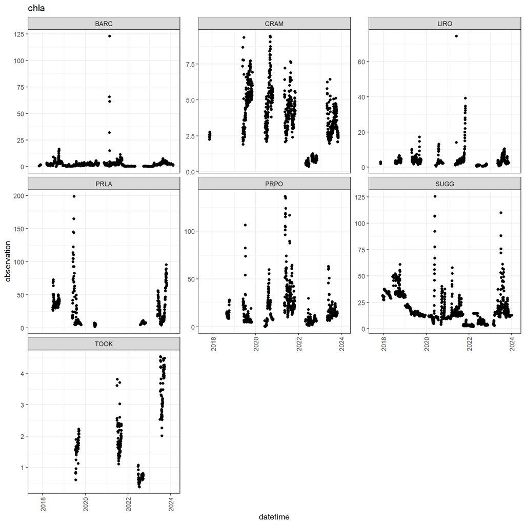

Figure: Chlorophyll targets data at aquatic sites provided by EFI for the NEON forecasting challgenge. Chlorophyll data is only available at lake and river sites

We can think about what type of models might be useful to predict these variables at these sites. Below are descriptions of three simple models which have been constructed to get you started forecasting:

- We could use information about current conditions to predict the next day. What is happening today is usually a good predictor of what will happen tomorrow (Model 2 - Persistence).
- We could also look at the lake variables’ relationship(s) with other variable. Could we use existing forecasts about the weather to generate forecasts about lake variables (Model 1 - Linear Model with Co-variates).
- And we could think about what the historic data tells us about this time of year. January this year is likely to be similar to January last year (Model 3 - Climatology/Seasonal Naive Model)

To start, we will produce forecasts for just one of these target variables, surface water temperature.

```r
targets <- targets %>%
  filter(variable == 'temperature')
```

# Introducing co-variates

One important step to overcome when thinking about generating forecasts is to include co-variates in the model. A water temperature forecast, for example, may be benefit from information about past and future weather. The neon4cast challenge package includes functions for downloading past and future NOAA weather forecasts for all of the NEON sites. The 3 types of data are as follows:

This code create a connection to the dataset hosted on the eco4cast server (`neon4cast-drivers/noaa/gefs-v12`) using `arrow` functions. To download the data you have to tell the function to `collect()` it. These data set can be subsetted and filtered using `dplyr` functions prior to download to limit the memory usage.

You can read more about the NOAA forecasts available for the NEON sites [here:](https://projects.ecoforecast.org/neon4cast-docs/Shared-Forecast-Drivers.html)

## Download co-variates

### Download historic data

We will generate a water temperature forecast using `air_temperature' and 'air_pressure` as a co-variates in multiple regression analysis. Note: This code chunk can take a few minutes to execute as it accesses the NOAA data.

```r
# past stacked weather
noaa_past_s3 <- neon4cast::noaa_stage3()

variables <- c("air_temperature", "air_pressure")
#Other variable names can be found at https://projects.ecoforecast.org/neon4cast-docs/Shared-Forecast-Drivers.html#stage-3

noaa_past <- noaa_past_s3  |>
  dplyr::filter(site_id %in% lake_sites$field_site_id,
                datetime >= ymd('2017-01-01'),
                variable %in% variables) |>
  dplyr::collect()

noaa_past
```

```
## # A tibble: 12,885,026 × 7
##    parameter datetime            variable   prediction family reference_datetime
##        <dbl> <dttm>              <chr>           <dbl> <chr>  <lgl>
##  1         0 2020-09-24 00:00:00 air_press…    101189. ensem… NA
##  2         1 2020-09-24 00:00:00 air_press…    101145. ensem… NA
##  3         2 2020-09-24 00:00:00 air_press…    101173. ensem… NA
##  4         3 2020-09-24 00:00:00 air_press…    101206. ensem… NA
##  5         4 2020-09-24 00:00:00 air_press…    101229. ensem… NA
##  6         5 2020-09-24 00:00:00 air_press…    101209. ensem… NA
##  7         6 2020-09-24 00:00:00 air_press…    101162. ensem… NA
##  8         7 2020-09-24 00:00:00 air_press…    101206. ensem… NA
##  9         8 2020-09-24 00:00:00 air_press…    101248. ensem… NA
## 10         9 2020-09-24 00:00:00 air_press…    101239. ensem… NA
## # ℹ 12,885,016 more rows
## # ℹ 1 more variable: site_id <chr>
```

This is a stacked ensemble forecast of the one day ahead forecasts. To get an estimate of the historic conditions we can take a mean of these ensembles. We will also need to convert the temperatures to Celsius from Kelvin.

```r
# aggregate the past to mean values
noaa_past_mean <- noaa_past |>
  mutate(datetime = as_date(datetime)) |>
  group_by(datetime, site_id, variable, parameter) |>
  summarize(prediction = mean(prediction, na.rm = TRUE), .groups = "drop") |>
  pivot_wider(names_from = variable, values_from = prediction) |>
  # convert air temp to C
  mutate(air_temperature = air_temperature - 273.15)
```

Calculate daily mean values for each site

```r
# aggregate the past to daily mean values
noaa_daily_mean <- noaa_past_mean |>
  mutate(datetime = as_date(datetime)) |>
  group_by(datetime, site_id) |>
  summarize(air_temperature = mean(air_temperature, na.rm = TRUE),
            air_pressure = mean(air_pressure, na.rm = TRUE), .groups = "drop")
```

Data wrangling of observed air temperature data at Lakes so we can plot observed and forecasted air temperature on one time series plot.

```r
#Bind lake water temperature to noaa past air temperature and pressure
#Also, pivot wider to join the water temp from targets to new dataframe to model
merged_df <- targets %>%
  pivot_wider(names_from = variable, values_from = observation)

#Join this dataset with noaa past mean to have all variables in a single df
model_df <- dplyr::left_join(merged_df, noaa_daily_mean, join_by("datetime", "site_id"), unmatched = "drop")
```

We can then look at the future weather forecasts in the same way but using the `noaa_stage2()`. The forecast becomes available from NOAA at 5am UTC the following day, so we take the air temperature forecast from yesterday (`noaa_date`) to make the water quality forecasts. Then we can use the ensembles to produce uncertainty in the water temperature forecast by forecasting multiple (31) future water temperatures.

### Download future weather forecasts

```r
# New forecast only available at 5am UTC the next day

forecast_date <- Sys.Date()
noaa_date <- forecast_date - days(1)

noaa_future_s3 <- neon4cast::noaa_stage2(start_date = as.character(noaa_date))
variables <- c("air_temperature","air_pressure")

noaa_future <- noaa_future_s3 |>
  dplyr::filter(datetime >= forecast_date,
                site_id %in% lake_sites$field_site_id,
                variable %in% variables) |>
  collect()
```

The forecasts are hourly and we are interested in using daily mean air temperature for water temperature forecast generation.

```r
noaa_future_daily <- noaa_future |>
  mutate(datetime = as_date(datetime)) |>
  # mean daily forecasts at each site per ensemble
  group_by(datetime, site_id, parameter, variable) |>
  summarize(prediction = mean(prediction)) |>
  pivot_wider(names_from = variable, values_from = prediction) |>
  # convert to Celsius
  mutate(air_temperature = air_temperature - 273.15) |>
  select(datetime, site_id, air_temperature, air_pressure, parameter)
noaa_future_daily
```

```
## # A tibble: 7,595 × 5
## # Groups:   datetime, site_id, parameter [7,595]
##    datetime   site_id air_temperature air_pressure parameter
##    <date>     <chr>             <dbl>        <dbl>     <dbl>
##  1 2024-02-12 BARC               21.2      100867.         0
##  2 2024-02-12 BARC               21.6      100846.         1
##  3 2024-02-12 BARC               21.4      100842.         2
##  4 2024-02-12 BARC               21.2      100896.         3
##  5 2024-02-12 BARC               21.1      100860.         4
##  6 2024-02-12 BARC               21.2      100836.         5
##  7 2024-02-12 BARC               21.1      100875.         6
##  8 2024-02-12 BARC               21.3      100975.         7
##  9 2024-02-12 BARC               22.0      100825.         8
## 10 2024-02-12 BARC               21.3      100899.         9
## # ℹ 7,585 more rows
```

Select the observed and modeled air temperature forecast for your forecasting time period

```r
for(i in 1:length(lake_sites$field_site_id)) {
forecast_start_date <- Sys.Date()

past_lake_temp <- noaa_daily_mean %>%
  filter(datetime >= "2024-02-07" & datetime <= "2024-02-18") %>%
  mutate(air_temperature = ifelse(datetime > forecast_start_date, NA, air_temperature),
         air_pressure = ifelse(datetime > forecast_start_date, NA, air_pressure))

#select the date range for noaa air temperature values as well
future_lake_temp <- noaa_future_daily %>%
  filter(datetime >= "2024-02-07" & datetime <= "2024-02-18")
  #mutate(air_temperature = ifelse(datetime > forecast_start_date, NA, air_temperature),
         #air_pressure = ifelse(datetime > forecast_start_date, NA, air_pressure))

}
```

Plot the timeseries for all the lakes for the forecast interval of your interest.

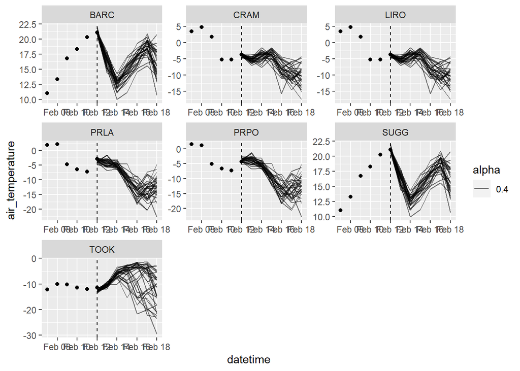

```r
ggplot(past_lake_temp, aes(x=datetime, y=air_temperature)) +
  geom_point()+
  geom_line(data = future_lake_temp, aes(x=datetime, y=air_temperature, group = parameter, alpha = 0.4)) +
  geom_vline(xintercept = as_date(forecast_start_date), linetype = "dashed") +
  facet_wrap(~site_id, scales = 'free')
```

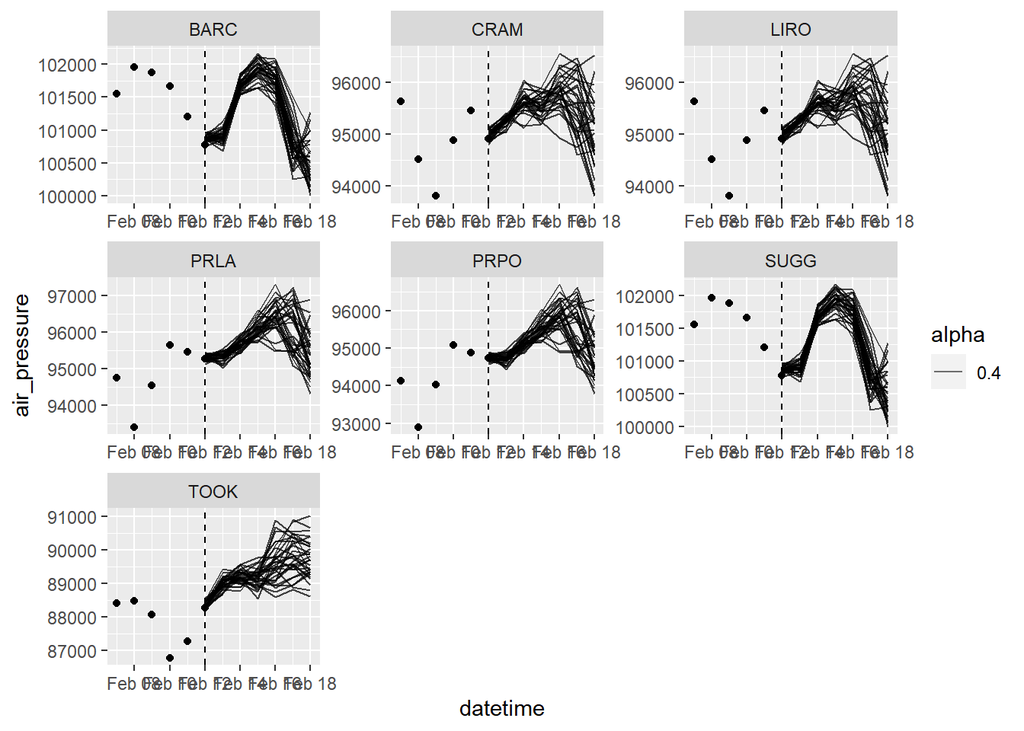

```r
ggplot(past_lake_temp, aes(x=datetime, y=air_pressure)) +
  geom_point()+
  geom_line(data = future_lake_temp, aes(x=datetime, y=air_pressure, group = parameter, alpha = 0.4)) +
  geom_vline(xintercept = as_date(forecast_start_date), linetype = "dashed") +
  geom_line(data = future_lake_temp, aes(group = parameter), alpha = 0.4)+
  facet_wrap(~site_id, scales = 'free')
```

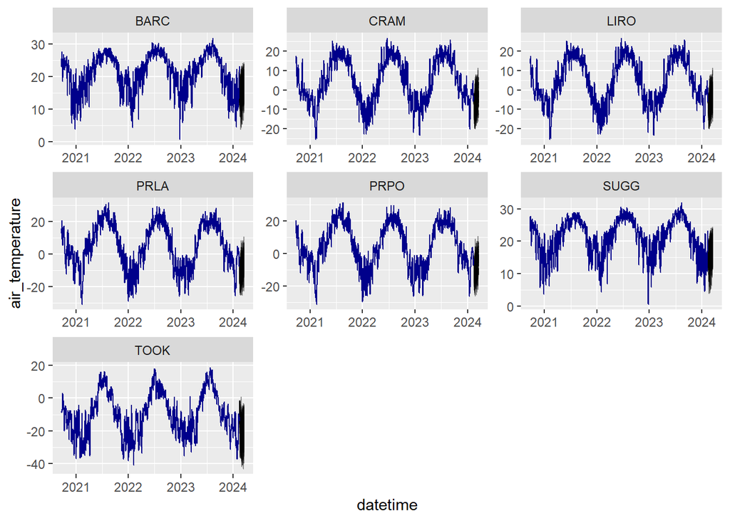

Figure: historic and future NOAA air temeprature forecasts at lake sites

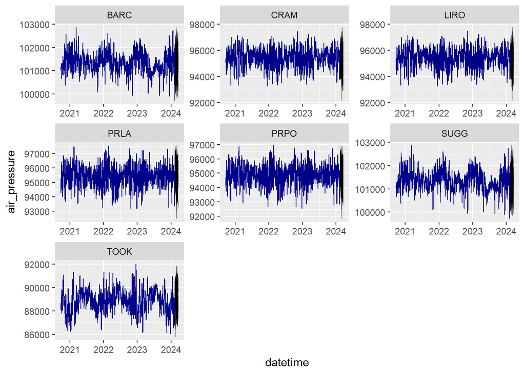

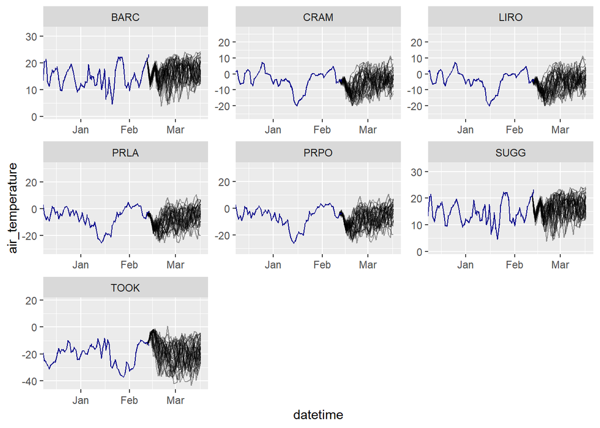

Figure: historic and future NOAA air temeprature forecasts at lake sites

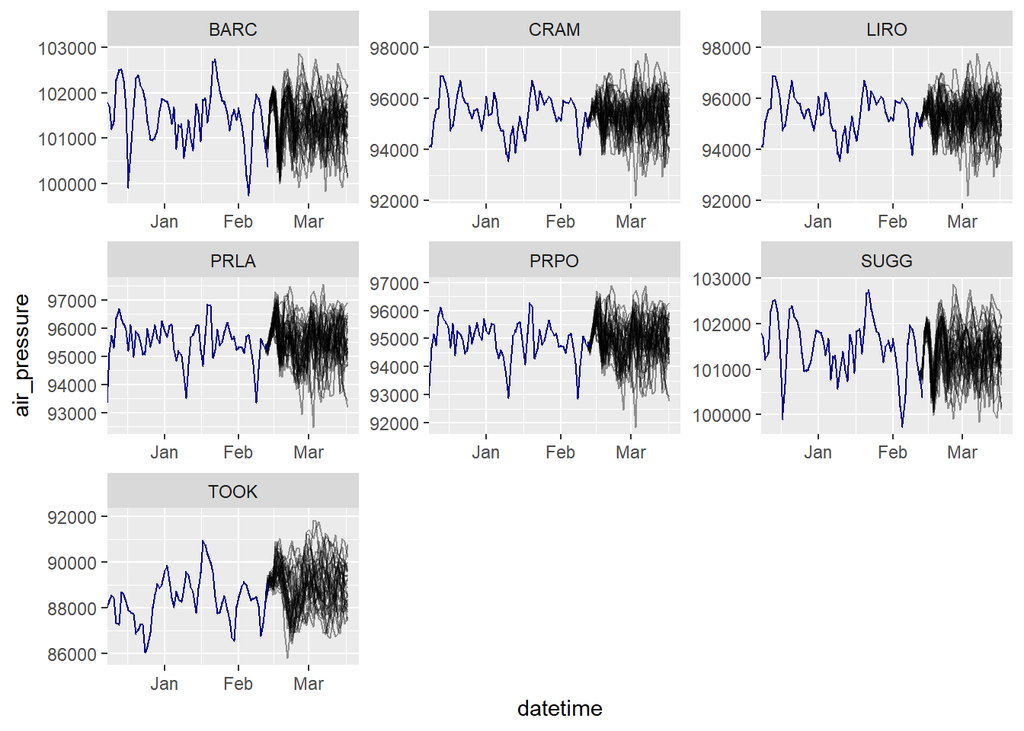

# Model 1: Linear model with covariates

We will start by joining the historic weather data with the targets to aid in fitting the linear model.

### Fit model

First, build a data frame to fit the model. We will create a column `wtemp_yday` which is a column of 1-day lags of water temperature.

```r
model_lag_data <- model_df %>%
  group_by(site_id) %>%
  mutate(wtemp_yday = lag(temperature))
head(model_lag_data)
```

```
## # A tibble: 6 × 6
## # Groups:   site_id [1]
##   datetime   site_id temperature air_temperature air_pressure wtemp_yday
##   <date>     <chr>         <dbl>           <dbl>        <dbl>      <dbl>
## 1 2017-08-27 BARC           31.5              NA           NA       NA
## 2 2017-08-28 BARC           31.1              NA           NA       31.5
## 3 2017-08-29 BARC           31.1              NA           NA       31.1
## 4 2017-08-30 BARC           31.4              NA           NA       31.1
## 5 2017-08-31 BARC           31.7              NA           NA       31.4
## 6 2017-09-01 BARC           31.6              NA           NA       31.7
```

```r
#targets_lm <- targets |>
  #filter(variable == 'temperature') |>
  #pivot_wider(names_from = 'variable', values_from = 'observation') |>
  #left_join(noaa_past_mean,
            #by = c("datetime","site_id"))

#targets_lm[1000:1010,]
```

To fit the linear model we use the base R `lm()` but there are also methods to fit linear (and non-linear) models in the `fable::` package. You can explore the [documentation](https://otexts.com/fpp3/regression.html) for more information on the `fable::TSLM()` function. We can fit a separate linear model for each site. For example, at Lake Suggs, this would look like:

```r
#example_site <- 'SUGG'

#site_target <- targets_lm |>
  #filter(site_id == example_site)

#noaa_future_site <- noaa_future_daily |>
 # filter(site_id == example_site)

#Fit linear model based on past data: water temperature = m * air temperature + b
#fit <- lm(site_target$temperature ~ site_target$air_temperature*site_target$air_pressure)
#summary(fit)

# use linear regression to forecast water temperature for each ensemble member
#forecasted_temperature <- fit$coefficients[1] + fit$coefficients[2] * noaa_future_site$air_temperature + fit$coefficients[3] * noaa_future_site$air_pressure
```

We can loop through this for each site to create a site-wise forecast of water temperature based on a linear model and each forecasted air temperature. We can run this forecast for each site and then bind them together to submit as one forecast.

## Specify forecast model

```r
temp_lm_forecast <- NULL
temp_lm_forecast_allsites <- NULL
temp_lm_past_predict <- NULL

for(i in 1:length(lake_sites$field_site_id)) {
  #selects the site that comes first on the loop from all lake site dataset created above
  example_site <- lake_sites$field_site_id[i]
  #pulls all the data related to selected site from the target dataset used to model
  site_target <- model_lag_data |>
    filter(site_id == example_site)
  #pulls all the data related to selected site from the noaa future daily dataset
  noaa_future_site <- future_lake_temp |>
    filter(site_id == example_site)

  #Fit linear model based on past data: water temperature = m * air temperature + b
  fit <- lm(site_target$temperature ~ site_target$air_temperature + site_target$air_pressure + site_target$wtemp_yday)
  fit_summary <- summary(fit)
  fit_summary

  #Predict water temperature for the past time of your forecast period of interest using the same model
  past_predict <- past_lake_temp %>%
    filter(site_id == example_site)
  pp_wtemp = fit$coefficients[1] + fit$coefficients[2] *past_predict$air_temperature + fit$coefficients[3] * past_predict$air_pressure

  # put all the relevant information into a tibble that we can bind together
  wtemp_pastperiod <- tibble(datetime = past_predict$datetime,
                        site_id = example_site,
                        wtemp = pp_wtemp,
                        variable = "wtemperature")
  temp_lm_past_predict <- dplyr::bind_rows(temp_lm_past_predict, wtemp_pastperiod)

  #Predict water temp for your forecasting period to use lag wtemp values
  noaa_future_site$fcast_wtemp = fit$coefficients[1] + fit$coefficients[2] * noaa_future_site$air_temperature + fit$coefficients[3] * noaa_future_site$air_pressure

  # put all the relevant information into a tibble that we can bind together
  wtemp_toplot <- tibble(datetime = noaa_future_site$datetime,
                        site_id = example_site,
                        parameter = noaa_future_site$parameter,
                        wtemp = noaa_future_site$fcast_wtemp,
                        variable = "wtemperature")
  temp_lm_forecast_allsites <- dplyr::bind_rows(temp_lm_forecast_allsites, wtemp_toplot)

  #Create a lag and use yesterday's water temp to predict future water temperature
  my_lag_data <-  noaa_future_site %>%
    group_by(datetime) %>%
    summarize(fcast_wtemp = mean(fcast_wtemp)) %>%
  mutate(fwtemp_yday = lag(fcast_wtemp))

  #Equalize number of rows in site target and future data
  a <- nrow(site_target)
  b <- nrow(noaa_future_site)
  n <- a-b
  for(i in 1:(n)) {
  proxy <- tibble(datetime = NA,
                        site_id = NA,
                        parameter = NA)

  noaa_future_site <- dplyr::bind_rows(noaa_future_site, proxy)
  }

  # use linear regression to forecast water temperature for each ensemble member
  forecasted_temperature <- fit$coefficients[1] + fit$coefficients[2] * noaa_future_site$air_temperature + fit$coefficients[3] * noaa_future_site$air_pressure + fit$coefficients[4] * my_lag_data$fwtemp_yday


  # put all the relevant information into a tibble that we can bind together
  temperature <- tibble(datetime = noaa_future_site$datetime,
                        site_id = example_site,
                        parameter = noaa_future_site$parameter,
                        prediction = forecasted_temperature,
                        variable = "temperature")

  temp_lm_forecast <- dplyr::bind_rows(temp_lm_forecast, temperature)
  message(example_site, ' temperature forecast run')

}
```

```
## BARC temperature forecast run
```

```
## CRAM temperature forecast run
```

```
## LIRO temperature forecast run
```

```
## PRLA temperature forecast run
```

```
## PRPO temperature forecast run
```

```
## SUGG temperature forecast run
```

```
## TOOK temperature forecast run
```

```r
#remove all NAs from the dataset
temp_lm_forecast_noNA <- temp_lm_forecast[!rowSums(is.na(temp_lm_forecast[1:5])), ]
```

Looking back at the forecasts we produced:

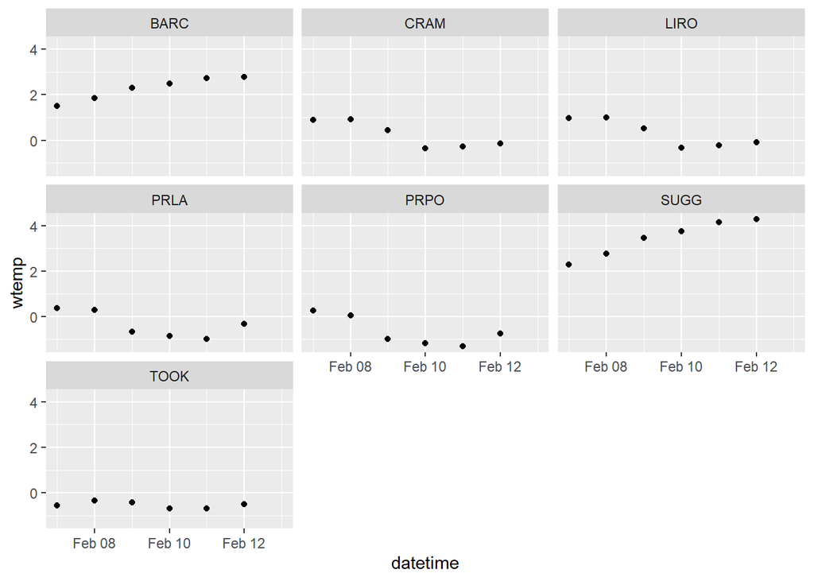

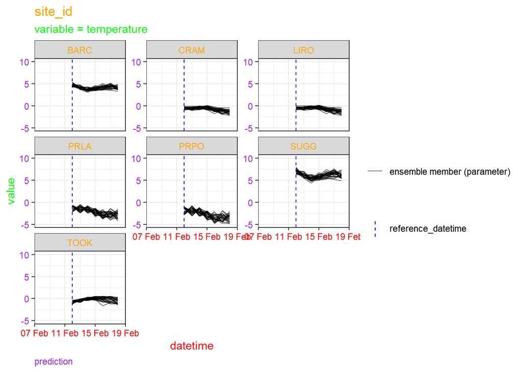

Combined plot of the past and future water temperature prediction for your time period of interest.

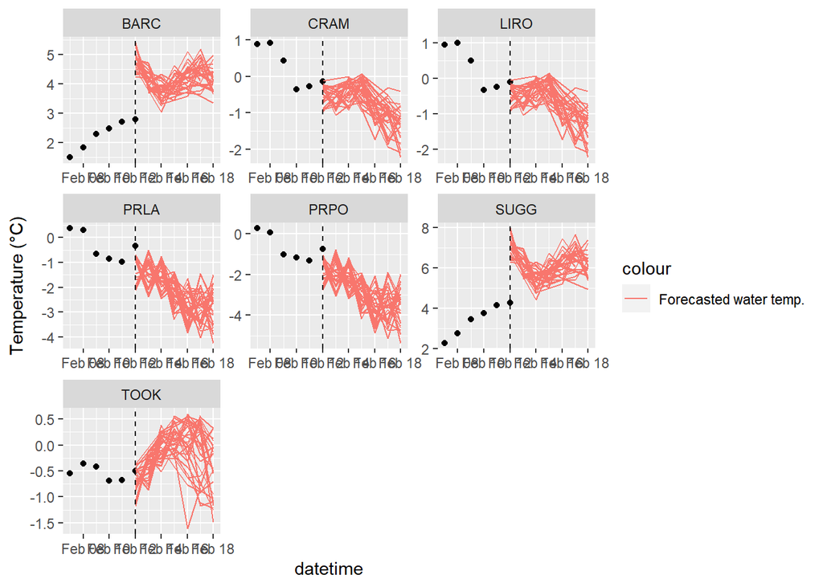

```r
ggplot() +
  geom_point(data = temp_lm_past_predict, aes(x=datetime, y=wtemp))+
    geom_line(data = temp_lm_forecast_noNA, aes(x = datetime, y = prediction, color = "Forecasted water temp.", group = parameter)) +
    geom_vline(xintercept = as_date(forecast_start_date), linetype = "dashed") +
    ylab("Temperature (\u00B0C)")+
  facet_wrap(~site_id, scales = 'free')
```

```r
for(i in 1:length(lake_sites$field_site_id)) {
  #selects the site that comes first on the loop from all lake site dataset created above
  example_site <- lake_sites$field_site_id[i]
  #pulls all the data related to selected site from the target dataset used to model
  site_target <- past_lake_temp |>
    filter(site_id == example_site)
  #pulls all the data related to selected site from the noaa future daily dataset
  noaa_future_site <- future_lake_temp |>
    filter(site_id == example_site)

  #Predict water temp for your forecasting period to use lag wtemp values
  past_wtemp = fit$coefficients[1] + fit$coefficients[2] * past_lake_temp$air_temperature + fit$coefficients[3] * past_lake_temp$air_pressure

}
```

Calculate model predictions. Clean the dataframe removing all rows with NAs.

```r
#noNA <- model_df[!rowSums(is.na(model_df[1:5])), ]
```

```r
#mod <- predict(fit, data = noNA)
#mod <- c(NA, mod)
```

Assess model fit by calculating $R^2$ (`r2`), mean bias (`err`), and RMSE (`RMSE`).

```r
r2 <- round(fit_summary$r.squared, 2)
#remove all NAs from the dataset
#noaa_future_site_noNA <- noaa_future_site[!rowSums(is.na(noaa_future_site[1:6])), ]
#make a data.frame with 10 rows of NA
na_frame <- as.data.frame(matrix(NA, nrow = 217, ncol = 5))
#add the names of mtcars
names(na_frame) <- names(temp_lm_forecast_noNA)
#bind together
temp_lm_forecast_noNA <- dplyr::bind_rows(temp_lm_forecast_noNA, na_frame)
residuals <- temp_lm_forecast_noNA$prediction - temp_lm_forecast_allsites$wtemp
err <- mean(residuals, na.rm = TRUE)
rmse <- round(sqrt(mean((temp_lm_forecast_noNA$prediction - temp_lm_forecast_allsites$wtemp)^2, na.rm = TRUE)), 2)
```

Prepare data frames for plotting.

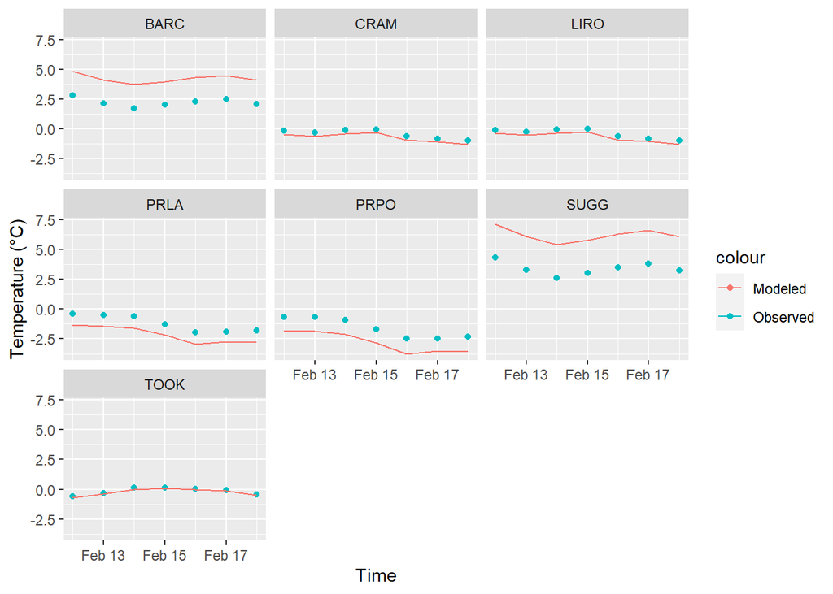

```r
plot_fcast <- temp_lm_forecast_allsites %>%
  group_by(datetime, site_id) %>%
  summarize(wtemp = mean(wtemp)) %>%
  filter(datetime >= "2024-02-11" & datetime <= "2024-02-18")
plot_mod <-  temp_lm_forecast_noNA %>%
  group_by(datetime, site_id) %>%
  summarize(prediction = mean(prediction)) %>%
  filter(datetime >= "2024-02-11" & datetime <= "2024-02-18")
ggplot() +
    geom_point(data = plot_fcast, aes(datetime, wtemp, color = "Observed")) +
    geom_line(data = plot_mod, aes(datetime, prediction, color = "Modeled")) +
    ylab("Temperature (\u00B0C)") +
    xlab("Time")+
  facet_wrap(~site_id)
```

### Run Deterministic Water Temperature Forecast

Set the number of ensemble members; this is set to 1 because we are making a deterministic forecast.

```r
n_members <- 1
```

```r
forecast_horizon <- 6
forecasted_dates <- seq(from = ymd(forecast_start_date), to = ymd(forecast_start_date) + forecast_horizon, by = "day")
```

Pull the current observed water temperature as our initial, or starting, condition.

```r
#temp_lm_forecast_mean <- temp_lm_forecast %>%
  # mean daily forecasts at each site per ensemble
  #group_by(datetime, site_id) |>
  #summarize(prediction = mean(prediction))
  #pivot_wider(names_from = variable, values_from = prediction)

for(i in 1:length(lake_sites$field_site_id)) {
curr_wt <- my_lag_data %>%
  filter(datetime == forecast_start_date) %>%
  pull(fcast_wtemp)
}
```

Setting up an empty dataframe that we will fill with our water temperature predictions. Here, the `mutate()` function is used to insert the current observed water temperature as the initial condition and set all future values of water temperature to NA, which will subsequently be replaced with forecasted values by our model.

```r
forecast_deterministic1 <- NULL
for(i in 1:length(lake_sites$field_site_id)) {

  example_site <- lake_sites$field_site_id[i]

  #pull current water temperature data for all sites
  mean_current_wtemp <-  temp_lm_forecast_allsites %>%
    group_by(datetime, site_id) %>%
    summarize(wtemp = mean(wtemp))

  curr_wt <- mean_current_wtemp %>%
  filter(datetime == forecast_start_date & site_id == example_site) %>%
  pull(wtemp)

  #store it in the forecast probabilistic table for all sites
forecast_deterministic <- tibble(forecast_date = rep(forecasted_dates, times = n_members),
                                 parameter = rep(1:n_members, each = length(forecasted_dates)),
                                 forecast_variable = "water_temperature",
                                 site_id = example_site,
                                 value = as.double(NA),
                                 uc_type = "deterministic") %>%
  mutate(value = ifelse(forecast_date == forecast_start_date, curr_wt, NA))

forecast_deterministic1 <- dplyr::bind_rows(forecast_deterministic1, forecast_deterministic)
}
```

```r
for(i in 1:length(lake_sites$field_site_id)) {

  example_site <- lake_sites$field_site_id[i]

for(i in 2:length(forecasted_dates)) {

  #pull prediction dataframe for the relevant date
  temp_pred <- forecast_deterministic1 %>%
    filter(forecast_date == forecasted_dates[i])

  #pull driver data for the relevant date; here we select only 1 ensemble member from the NOAA air temperature forecast
  temp_driv <- future_lake_temp %>%
    filter(datetime == forecasted_dates[i] & parameter == 1)

  #pull lagged water temp values
  temp_lag <- my_lag_data %>%
    filter(forecast_date == forecasted_dates[i-1])

  #run model
  temp_pred$value <- fit$coefficients[1] + temp_driv$air_temperature* fit$coefficients[2] + temp_driv$air_pressure * fit$coefficients[3]

  #insert values back into the forecast dataframe
  forecast_deterministic1 <- forecast_deterministic1 %>%
    rows_update(temp_pred, by = c("forecast_date","parameter","forecast_variable", "site_id", "uc_type"))
}
}
```

```r
past1 <- past_lake_temp %>%
  filter(datetime <= "2024-02-10")
```

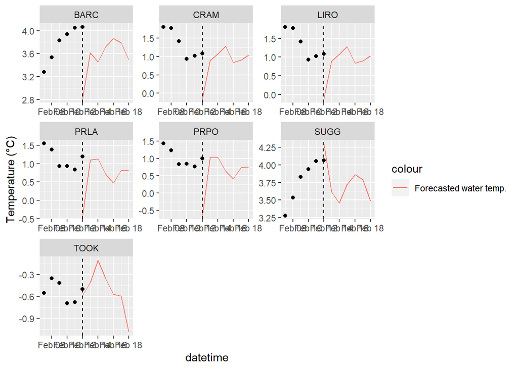

```r
#temp_lm_f_mean <- temp_lm_forecast_mean %>%
  #filter(datetime <= "2024-02-10")
ggplot() +
  geom_point(data = past_lake_temp, aes(x=datetime, y=past_wtemp))+
    geom_line(data = forecast_deterministic1, aes(x = forecast_date, y = value, color = "Forecasted water temp.", group = parameter)) +
    geom_vline(xintercept = as_date(forecast_start_date), linetype = "dashed") +
    ylab("Temperature (\u00B0C)")+
  facet_wrap(~site_id, scales = 'free')
```

Set number of ensemble members; notice we now use the entire NOAA forecast ensemble with 30 members.

```r
n_members <- 30
```

Setting up an empty dataframe that we will fill with our water temperature predictions. Notice that this dataframe is much longer than the `forecast_deterministic` dataframe because we are now forecasting with 30 ensemble members.

```r
forecast_driver_unc1 <- NULL
for(i in 1:length(lake_sites$field_site_id)) {

  example_site <- lake_sites$field_site_id[i]

  #pull current water temperature data for all sites
  mean_current_wtemp <-  temp_lm_forecast_allsites %>%
    group_by(datetime, site_id) %>%
    summarize(wtemp = mean(wtemp))

  curr_wt <- mean_current_wtemp %>%
  filter(datetime == forecast_start_date & site_id == example_site) %>%
  pull(wtemp)
forecast_driver_unc <- tibble(forecast_date = rep(forecasted_dates, times = n_members),
                              parameter = rep(1:n_members, each = length(forecasted_dates)),
                              forecast_variable = "water_temperature",
                              site_id = example_site,
                              value = as.double(NA),
                              uc_type = "driver") %>%
  mutate(value = ifelse(forecast_date == forecast_start_date, curr_wt, NA))
forecast_driver_unc1 <- dplyr::bind_rows(forecast_driver_unc1, forecast_driver_unc)
}
```

Run forecast. Notice that we now pull the entire driver ensemble of the NOAA forecast for each day instead of just ensemble member 1.

```r
for(i in 1:length(lake_sites$field_site_id)) {

  example_site <- lake_sites$field_site_id[i]

for(i in 2:length(forecasted_dates)) {

  #pull prediction dataframe for the relevant date
  temp_pred <- forecast_driver_unc1 %>%
    filter(forecast_date == forecasted_dates[i] & site_id == example_site)

  #pull driver ensemble for the relevant date; here we are using all 30 NOAA ensemble members
  temp_driv <- future_lake_temp %>%
    filter(datetime == forecasted_dates[i] & site_id == example_site & parameter >= 1)

  #pull lagged water temp values
  temp_lag <- forecast_driver_unc1 %>%
    filter(forecast_date == forecasted_dates[i-1])

  #run model
   temp_pred$value <- fit$coefficients[1] + temp_driv$air_temperature* fit$coefficients[2] +     temp_driv$air_pressure * fit$coefficients[3]

  #insert values back into the forecast dataframe
  forecast_driver_unc1 <- forecast_driver_unc1 %>%
    rows_update(temp_pred, by = c("forecast_date","parameter","forecast_variable", "site_id", "uc_type"))
}
}
```

Plot the forecast.

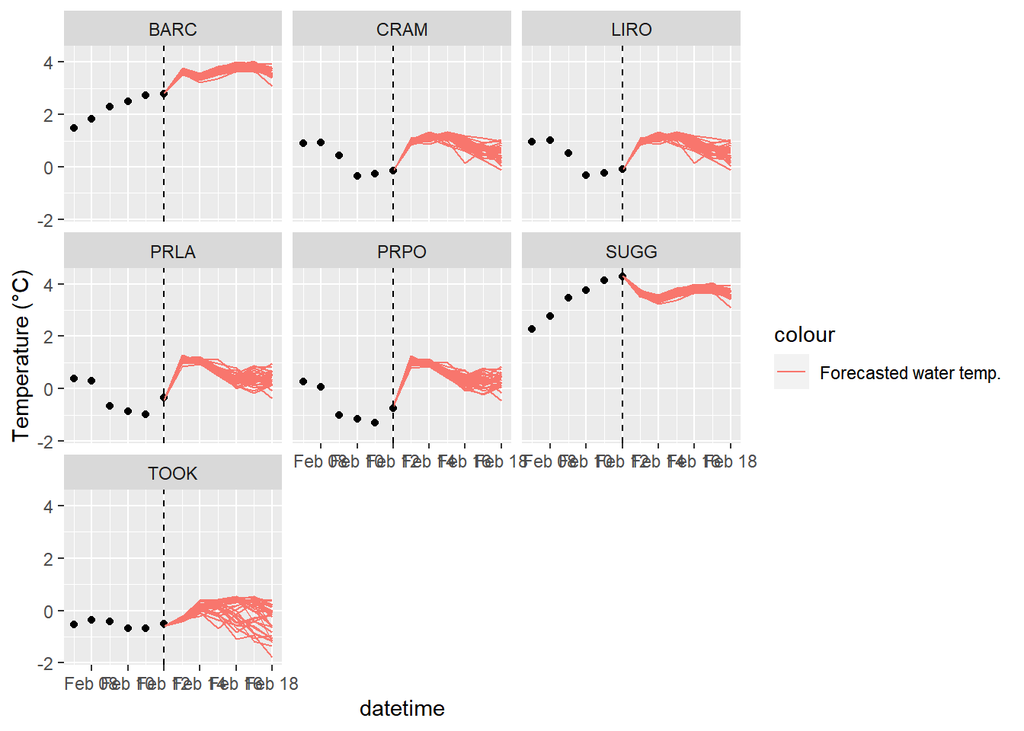

```r
ggplot() +
    geom_point(data = temp_lm_past_predict, aes(x=datetime, y=wtemp))+
    geom_line(data = forecast_driver_unc1, aes(x = forecast_date, y = value, color = "Forecasted water temp.", group = parameter)) +
    geom_vline(xintercept = as_date(forecast_start_date), linetype = "dashed") +
    ylab("Temperature (\u00B0C)")+
  facet_wrap(~site_id)
```

#Parameter Uncertainty Use the `rnorm()` function and the information in the `coeffs` and `params_se` objects to generate parameter distributions for each of the parameters in the multiple regression model.

View standard errors of estimated model coefficients and save them for our forecasts later.

```r
params_se <- fit_summary$coefficients[,2]
params_se
```

```
##                 (Intercept) site_target$air_temperature
##                4.034555e+00                6.229140e-03
##    site_target$air_pressure      site_target$wtemp_yday
##                4.557529e-05                9.741050e-03
```

```r
param_df <- data.frame(beta1 = rnorm(30, fit$coefficients[1], params_se[1]),
                       beta2 = rnorm(30, fit$coefficients[2], params_se[2]),
                       beta3 = rnorm(30, fit$coefficients[3], params_se[3]))
```

Plot each of the parameter distributions you have created.

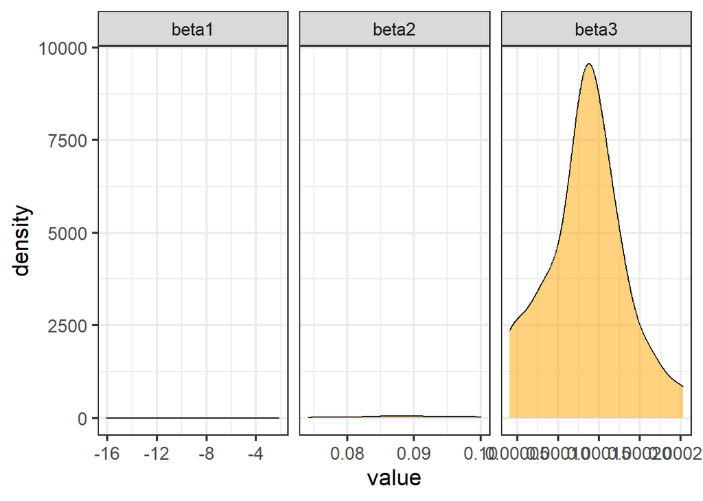

```r
#plot_param_dist <- function(param_df)
  # Set colors
  #l.cols <- RColorBrewer::brewer.pal(8, "Set2")[-c(1, 2)] # Defining another custom color palette :-)

  # Reshape data
  plot.params <- pivot_longer(param_df, cols = starts_with("beta"), names_to = "variable", values_to = "value")

  # Build plot
  ggplot(plot.params) +
    geom_density(aes(value), fill = "orange", alpha = 0.5) +
    facet_wrap(~variable, nrow = 1, scales = "free_x") +
    theme_bw(base_size = 16)
```

Setting up an empty dataframe that we will fill with our water temperature predictions.

```r
forecast_parameter_unc1 <- NULL
for(i in 1:length(lake_sites$field_site_id)) {

  example_site <- lake_sites$field_site_id[i]

  #pull current water temperature data for all sites
  mean_current_wtemp <-  temp_lm_forecast_allsites %>%
    group_by(datetime, site_id) %>%
    summarize(wtemp = mean(wtemp))

  curr_wt <- mean_current_wtemp %>%
  filter(datetime == forecast_start_date & site_id == example_site) %>%
  pull(wtemp)

forecast_parameter_unc <- tibble(forecast_date = rep(forecasted_dates, times = n_members),
                                 parameter = rep(1:n_members, each = length(forecasted_dates)),
                                 forecast_variable = "water_temperature",
                                 site_id = example_site,
                                 value = as.double(NA),
                                 uc_type = "parameter") %>%
  mutate(value = ifelse(forecast_date == forecast_start_date, curr_wt, NA))
forecast_parameter_unc1 <- dplyr::bind_rows(forecast_parameter_unc1, forecast_parameter_unc)
}
```

Run forecast.

**Notice** that parameter values are now pulled from our `param_df` distributions instead of the `coeffs` object, so our parameter values are now uncertain rather than fixed.

```r
for(i in 1:length(lake_sites$field_site_id)) {

  example_site <- lake_sites$field_site_id[i]

for(i in 2:length(forecasted_dates)) {

  #pull prediction dataframe for the relevant date
  temp_pred <- forecast_parameter_unc1 %>%
    filter(forecast_date == forecasted_dates[i] & parameter >=1)

  #pull driver data for the relevant date; here we select only 1 ensemble member from the NOAA air temperature forecast
  temp_driv <- future_lake_temp %>%
    filter(datetime == forecasted_dates[i] & parameter >=1)

  #pull lagged water temp values
  temp_lag <- forecast_parameter_unc1 %>%
    filter(forecast_date == forecasted_dates[i-1])

  #run model using parameter distributions instead of fixed values
  temp_pred$value <- param_df$beta1 + temp_driv$air_temperature * param_df$beta2 + temp_driv$air_pressure * param_df$beta3


  #insert values back into the forecast dataframe
  forecast_parameter_unc1 <- forecast_parameter_unc1 %>%
    rows_update(temp_pred, by = c("forecast_date","parameter","forecast_variable", "site_id", "uc_type"))
}
}
```

Build plot - this should resemble the water temperature forecast plot in the R Shiny app, Activity B Objective 7 (“Both” model)

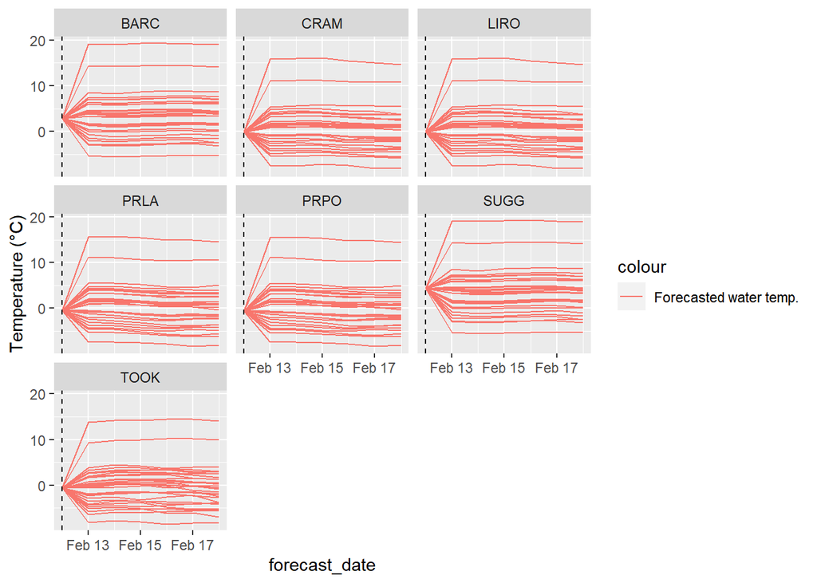

```r
ggplot() +
    #geom_point(data = temp_lm_forecast_mean, aes(x = datetime, y = temperature, color = "Observed water temp.")) +
    geom_line(data = forecast_parameter_unc1, aes(x = forecast_date, y = value, color = "Forecasted water temp.", group = parameter)) +
    geom_vline(xintercept = as_date(forecast_start_date), linetype = "dashed") +
    ylab("Temperature (\u00B0C)")+
  facet_wrap(~site_id)
```

#Process Uncertainty Define the standard deviation of the process uncertainty distribution, `sigma` as the standard deviation of the residuals. This is the uncertainty left over after we found the best parameters for fitting the model.

```r
sigma <- sd(residuals, na.rm = TRUE) # Process Uncertainty Noise Std Dev.; this is your sigma
```

Setting up an empty dataframe that we will fill with our water temperature predictions.

```r
forecast_process_unc <- tibble(forecast_date = rep(forecasted_dates, times = n_members),
                               parameter = rep(1:n_members, each = length(forecasted_dates)),
                               forecast_variable = "water_temperature",
                               value = as.double(NA),
                               uc_type = "process") %>%
  mutate(value = ifelse(forecast_date == forecast_start_date, curr_wt, NA))
```

Run forecast.

**Notice** that we only pull a single member of the NOAA air temperature forecast so that we can focus on the contribution of process uncertainty alone to our forecast.

**Notice** that process uncertainty is defined using the `rnorm()` function with a standard deviation of `sigma`.

```r
for(i in 1:length(lake_sites$field_site_id)) {

  example_site <- lake_sites$field_site_id[i]

for(i in 2:length(forecasted_dates)) {

  #pull prediction dataframe for the relevant date
  temp_pred <- forecast_process_unc %>%
    filter(forecast_date == forecasted_dates[i])

  #pull driver data for the relevant date; here we select only 1 ensemble member from the NOAA air temperature forecast
  temp_driv <- future_lake_temp %>%
    filter(datetime == forecasted_dates[i] & parameter == 1 & site_id == example_site)

  #pull lagged water temp values
  temp_lag <- forecast_process_unc %>%
    filter(forecast_date == forecasted_dates[i-1])

  #run model with process uncertainty added
  temp_pred$value <- fit$coefficients[1] + temp_driv$air_temperature * fit$coefficients[2] + temp_driv$air_pressure * fit$coefficients[3] + rnorm(n = 30, mean = 0, sd = sigma)

  #insert values back into the forecast dataframe
  forecast_process_unc <- forecast_process_unc %>%
    rows_update(temp_pred, by = c("forecast_date","parameter","forecast_variable","uc_type"))
}
}
```

Build plot - this should resemble the water temperature forecast plot in the R Shiny app, Activity B Objective 6 (“Both” model)

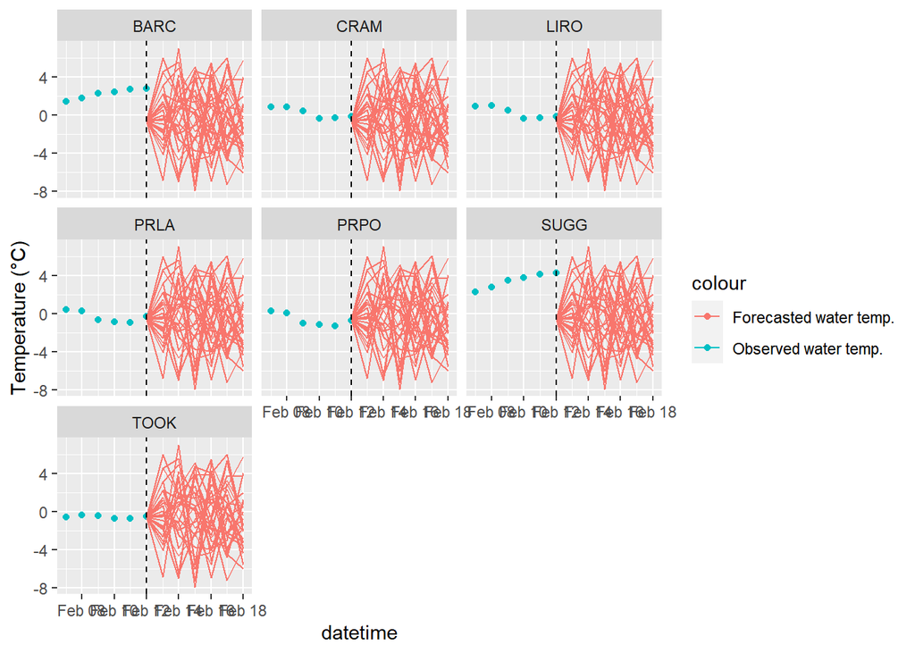

```r
ggplot() +
    geom_point(data = temp_lm_past_predict, aes(x = datetime, y = wtemp, color = "Observed water temp.")) +
    geom_line(data = forecast_process_unc, aes(x = forecast_date, y = value, color = "Forecasted water temp.", group = parameter)) +
    geom_vline(xintercept = as_date(forecast_start_date), linetype = "dashed") +
    ylab("Temperature (\u00B0C)")+
  facet_wrap(~site_id)
```

To account for initial condition uncertainty we can generate a distribution around the initial condition and then run our model with slightly different initial conditions.

Generate a distribution of initial conditions for your forecast using the current water temperature (`curr_wt`) and a standard deviation of 0.1 degrees Celsius (`ic_sd`).

```r
ic_uc1 <- NULL
ic_sd <- 0.1
for(i in 1:length(lake_sites$field_site_id)) {
  example_site <- lake_sites$field_site_id[i]

  curr_wt <- mean_current_wtemp %>%
  filter(datetime == forecast_start_date & site_id == example_site) %>%
  pull(wtemp)

ic_uc <- rnorm(n = n_members, mean = curr_wt, sd = ic_sd)
ic_uc1 <- append(ic_uc1, ic_uc)
}
```

Plot the distribution around your initial condition. This should resemble the initial condition distribution plot in the R Shiny app, Activity B Objective 8 (“Atemp” model).

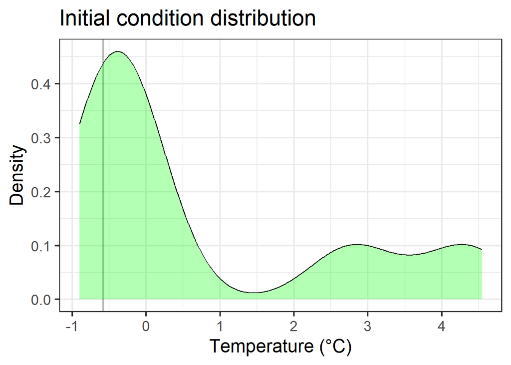

```r
#Build plot
  ggplot() +
    geom_vline(xintercept = curr_wt) +
    geom_density(aes(ic_uc1), fill = "green", alpha = 0.3) +
    xlab("Temperature (\u00B0C)") +
    ylab("Density") +
    theme_bw(base_size = 18)+
    ggtitle("Initial condition distribution")
```

Create dataframe with the distribution of initial conditions.

```r
ic_df1 <- NULL
for(i in 1:length(lake_sites$field_site_id)) {

  example_site <- lake_sites$field_site_id[i]

  for(i in 1:length(forecasted_dates)) {
  ic_uc <- rnorm(n = n_members, mean = curr_wt, sd = ic_sd)
ic_df <- tibble(forecast_date = rep(as.Date(forecasted_dates[i]), times = n_members),
                parameter = c(1:n_members),
                site_id = example_site,
                forecast_variable = "water_temperature",
                value = ic_uc,
                uc_type = "initial_conditions")
ic_df1 <- dplyr::bind_rows(ic_df1, ic_df)

}
}
```

Setting up an empty dataframe that we will fill with our water temperature predictions. **Note** the use of the `rows_update()` function to populate the starting date of the forecast with values from our initial conditions distribution.

```r
forecast_ic_unc1 <- NULL
for(i in 1:length(lake_sites$field_site_id)) {

  example_site <- lake_sites$field_site_id[i]

forecast_ic_unc <- tibble(forecast_date = rep(forecasted_dates, times = n_members),
                          parameter = rep(1:n_members, each = length(forecasted_dates)),
                          forecast_variable = "water_temperature",
                          value = as.double(NA),
                          site_id = example_site,
                          uc_type = "initial_conditions") %>%
  rows_update(ic_df1, by = c("forecast_date","parameter","forecast_variable", "site_id",
                            "uc_type"), unmatched = "ignore")

forecast_ic_unc1 <- dplyr::bind_rows(forecast_ic_unc1, forecast_ic_unc)
  }
```

Run forecast.

```r
for(i in 1:length(lake_sites$field_site_id)) {

  example_site <- lake_sites$field_site_id[i]

for(i in 1:length(forecasted_dates)) {

  #pull prediction dataframe for relevant date
  temp_pred <- ic_df1 %>%
    filter(forecast_date == forecasted_dates[i] & parameter == 1 & site_id == example_site)

  #pull driver data for the relevant date; here we select only 1 ensemble member from the NOAA air temperature forecast
  temp_driv <- future_lake_temp %>%
    filter(datetime == forecasted_dates[i] & parameter == 1 & site_id == example_site)

  #pull lagged water temp values
  temp_lag <- ic_df1 %>%
    filter(forecast_date == forecasted_dates[i])

  #run model using initial conditions distribution instead of a fixed value
  temp_pred$value <- fit$coefficients[1] + temp_driv$air_temperature * fit$coefficients[2] + temp_driv$air_pressure * fit$coefficients[3]

  #insert values back into the forecast dataframe
  forecast_ic_unc1 <- forecast_ic_unc1 %>%
    rows_update(temp_pred, by = c("forecast_date","parameter","forecast_variable", "site_id", "uc_type"))
}
}
```

Replace NAs in one dataset by values from another dataset

```r
forecast_ic_unc2 <- left_join(forecast_ic_unc1, ic_df1, by = c("forecast_date", "site_id", "parameter", "forecast_variable", "uc_type")) %>%
    mutate(value = ifelse(is.na(value.x), value.y, value.x)) %>%
    select(forecast_date, site_id, value, parameter, forecast_variable, uc_type)
```

Build plot - this should resemble the water temperature forecast plot in the R Shiny app, Activity B Objective 8 (“Both” model)

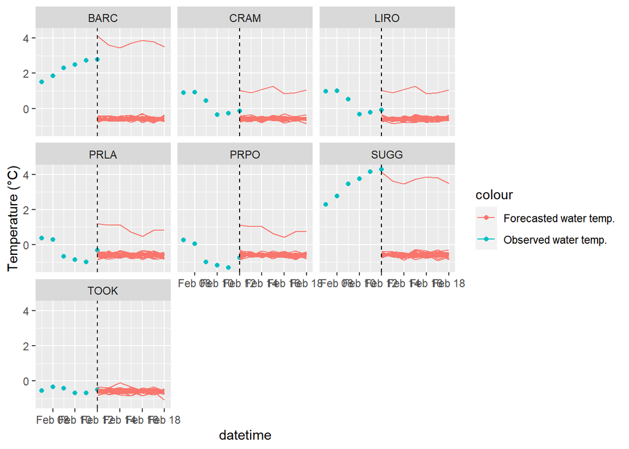

```r
ggplot() +
    geom_point(data = temp_lm_past_predict, aes(x = datetime, y = wtemp, color = "Observed water temp.")) +
    geom_line(data = forecast_ic_unc2, aes(x = forecast_date, y = value, color = "Forecasted water temp.", group = parameter)) +
    geom_vline(xintercept = as_date(forecast_start_date), linetype = "dashed") +
    ylab("Temperature (\u00B0C)")+
  facet_wrap(~site_id)
```

# Activity C:

## Objective 9. Generate a forecast incorporating all sources of uncertainty

To plot a forecast with all sources of uncertainty incorporated, we need to generate a forecast that incorporates driver, parameter, process, and initial conditions uncertainty.

Below, we will adjust the forecasting for-loop to incorporate all four sources of uncertainty (driver, parameter, process, initial conditions) into your forecasts. The forecast ensemble will have 30 members.

Setting up an empty dataframe that we will fill with our water temperature predictions. **Note** the use of the `rows_update()` function to populate the starting date of the forecast with values from our initial conditions distribution.

```r
forecast_total_unc1 <- NULL
for(i in 1:length(lake_sites$field_site_id)) {

  example_site <- lake_sites$field_site_id[i]
forecast_total_unc <- tibble(forecast_date = rep(forecasted_dates, times = n_members),
                             parameter = rep(1:n_members, each = length(forecasted_dates)),
                             forecast_variable = "water_temperature",
                             site_id = example_site,
                             value = as.double(NA),
                             uc_type = "total") %>%
  rows_update(ic_df1, by = c("forecast_date","parameter","forecast_variable", "site_id"), unmatched = "ignore")
forecast_total_unc1 <- dplyr::bind_rows(forecast_total_unc1, forecast_total_unc)
}
```

Run forecast. **Note** that we use all 30 NOAA air temperature forecast ensemble members, use a distribution of parameter values rather than fixed values, and have added process uncertainty to each iteration of our forecast.

```r
for(i in 1:length(lake_sites$field_site_id)) {

  example_site <- lake_sites$field_site_id[i]

for(i in 2:length(forecasted_dates)) {

  #pull prediction dataframe for relevant date
  temp_pred <- forecast_total_unc1 %>%
    filter(forecast_date == forecasted_dates[i])

  #pull driver ensemble for the relevant date; here we are using all 30 NOAA ensemble members
  temp_driv <- future_lake_temp %>%
    filter(datetime == forecasted_dates[i] & parameter >=1)

  #pull lagged water temp values
  temp_lag <- forecast_total_unc1 %>%
    filter(forecast_date == forecasted_dates[i-1])

  #Equalize number of rows in dataframe
  param_df1 <- param_df[-c(31:210), ]

  #run model using initial conditions and parameter distributions instead of fixed values, and adding process uncertainty
  temp_pred$value <- param_df1$beta1 + temp_driv$air_temperature * param_df1$beta2 + temp_driv$air_pressure * param_df1$beta3 + rnorm(n = 30, mean = 0, sd = sigma)

  #insert values back into the forecast dataframe
  forecast_total_unc1 <- forecast_total_unc1 %>%
    rows_update(temp_pred, by = c("forecast_date","parameter", "site_id", "uc_type"))
}
}
```

Build plot - this should resemble the water temperature forecast plot in the R Shiny app, Activity C Objective 10 (“Both” model)

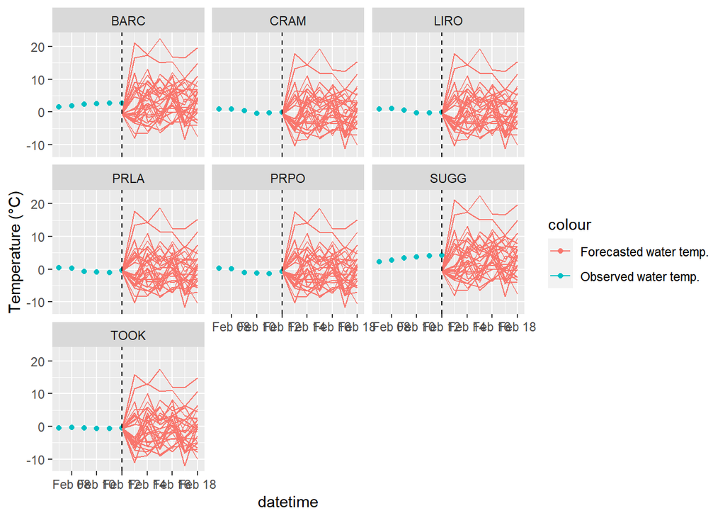

```r
ggplot() +
    geom_point(data = temp_lm_past_predict, aes(x = datetime, y = wtemp, color = "Observed water temp.")) +
    geom_line(data = forecast_total_unc1, aes(x = forecast_date, y = value, color = "Forecasted water temp.", group = parameter)) +
    geom_vline(xintercept = as_date(forecast_start_date), linetype = "dashed") +
    ylab("Temperature (\u00B0C)")+
  facet_wrap(~site_id)
```

## Objective 10. Partition uncertainty

Now, we will partition the relative contributions of each source of uncertainty to total forecast uncertainty.

Combine the forecasts with a single source of uncertainty into one dataframe.

```r
all_forecast_df <- bind_rows(forecast_driver_unc1, forecast_parameter_unc1) %>%
  bind_rows(., forecast_process_unc) %>%
  bind_rows(., forecast_ic_unc)
```

Group the dataframe by date and the type of uncertainty included in the forecast, then calculate the standard deviation across all 30 ensemble members for each date and uncertainty type.

```r
sd_df <- all_forecast_df %>%
  group_by(forecast_date, uc_type) %>%
  summarize(sd = sd(value, na.rm = TRUE), .groups = "drop")
```

Plot the contribution of each source of uncertainty to total forecast uncertainty. This should resemble the uncertainty quantification plot in the R Shiny app, Activity C, Objective 10 (“Atemp” model).

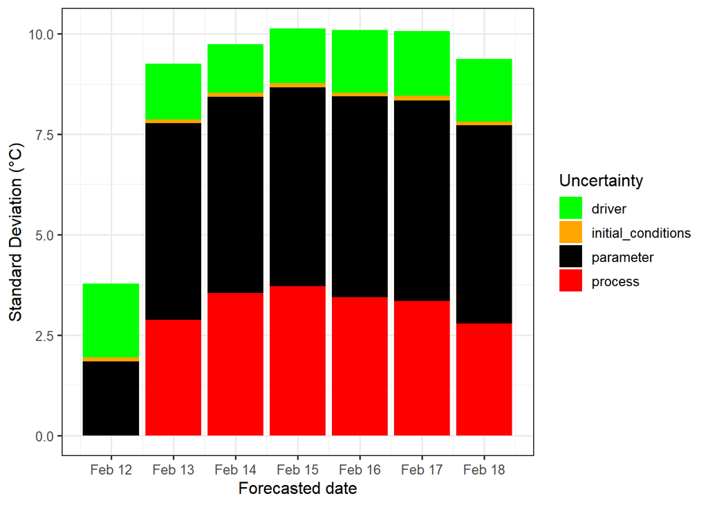

```r
  ggplot() +
    geom_bar(data = sd_df, aes(x = forecast_date, y = sd, fill = uc_type), stat = "identity", position = "stack") +
    ylab("Standard Deviation (\u00B0C)") +
    xlab("Forecasted date") +
    scale_fill_manual(values = c("process" = "red", "parameter" = "black", "initial_conditions" = "orange","driver" = "green")) +
    scale_x_date(date_breaks = "1 day", date_labels = "%b %d") +
    labs(fill = "Uncertainty") +
    theme_bw(base_size = 12)
```

## Convert to EFI standard for submission

For an ensemble forecast the documentation specifies the following columns:

- `datetime`: forecast timestamp for each time step
- `reference_datetime`: The start of the forecast; this should be 0 times steps in the future. This should only be one value of reference_datetime in the file
- `site_id`: NEON code for site
- `family`: name of probability distribution that is described by the parameter values in the parameter column; only `normal` or `ensemble` are currently allowed.
- `parameter`: integer value for forecast replicate (from the `.rep` in fable output);
- `variable`: standardized variable name from the theme
- `prediction`: forecasted value (from the `.sim` column in fable output)
- `model_id`: model name (no spaces). Any model_id that includes ‘example’ will not be included in analysis. It will still be evaluated against observations but will be deleted. This is good for testing and trying out new modelling ideas.

We need to make sure the dataframe is in the correct format and then we can submit this to the challenge as well! This is an ensemble forecast (specified in the `family` column).

```r
# Remember to change the model_id when you make changes to the model structure!
my_model_id <- 'example_Kandel'

temp_lm_forecast_EFI <- temp_lm_forecast %>%
  filter(datetime > forecast_date) %>%
  mutate(model_id = my_model_id,
         reference_datetime = forecast_date,
         family = 'ensemble',
         parameter = as.character(parameter)) %>%
  select(datetime, reference_datetime, site_id, family, parameter, variable, prediction, model_id)
```

## Submit forecast

Files need to be in the correct format for submission. The forecast organizers have created tools to help aid in the submission process. These tools can be downloaded from Github using `remotes::install_github(eco4cast/neon4cast)`. These include functions for submitting, scoring and reading forecasts:

- `submit()` - submit the forecast file to the neon4cast server where it will be scored
- `forecast_output_validator()` - will check the file is in the correct format to be submitted
- `check_submission()` - check that your submission has been uploaded to the server

The file name needs to be in the format theme-reference_datetime-model_id

```r
# Start by writing the forecast to file
theme <- 'aquatics'
date <- temp_lm_forecast_EFI$reference_datetime[1]
forecast_name_1 <- paste0(temp_lm_forecast_EFI$model_id[1], ".csv")
forecast_file_1 <- paste(theme, date, forecast_name_1, sep = '-')
forecast_file_1
```

```
## [1] "aquatics-2024-02-12-example_Kandel.csv"
```

```r
if (!dir.exists('Forecasts')) {
  dir.create('Forecasts')
}

write_csv(temp_lm_forecast_EFI, file.path('Forecasts',forecast_file_1))

neon4cast::forecast_output_validator(file.path('Forecasts',forecast_file_1))
```

```
## Forecasts/aquatics-2024-02-12-example_Kandel.csv
```

```
## ✔ file has model_id column
## ✔ forecasted variables found correct variable + prediction column
## ✔ file has correct family and parameter columns
## ✔ file has site_id column
## ✔ file has datetime column
## ✔ file has correct datetime column
```

```
## ✔ file has reference_datetime column
## Forecast format is valid
```

```
## [1] TRUE
```

```r
# can uses the neon4cast::forecast_output_validator() to check the forecast is in the right format
neon4cast::submit(forecast_file = file.path('Forecasts', forecast_file_1),
                  ask = FALSE) # if ask = T (default), it will produce a pop-up box asking if you want to submit
```

Is the linear model a reasonable relationship between air temperature and water temperature? Would some non-linear relationship be better? What about using yesterday’s air and water temperatures to predict tomorrow? Or including additional parameters? There’s a lot of variability in water temperatures unexplained by air temperature alone. Could we use the residuals from this fit to add an extra source of uncertainty?

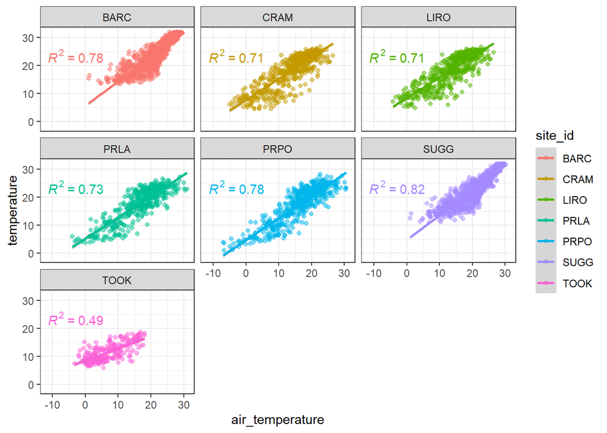